# Lab 01 - SOLUTIONS

This lab introduces you to Markdown, a popular ‘language’ for creating data-driven reports. This week you will practice some simple formatting rules using the [Markdown Tutorial](https://github.com/adam-p/markdown-here/wiki/Markdown-Cheatsheet) created by Adam Pritchard.

## Lab Instructions

Create a short bio for the class. Each question requires a different type of text or media. Use [Markdown](https://github.com/adam-p/markdown-here/wiki/Markdown-Cheatsheet) to format each answer correctly.

1. Add your name to a **Header 1** element called, “Bio of YOUR NAME”.
2. Add a **picture** of yourself to the bio.
3. Write a short **paragraph** about why you joined this class.
4. Create a **list** of three fun facts about yourself.
5. Add a **link** to the website of your degree program of study at ASU.
6. OPTIONAL: Embed a YouTube **video** of a weird song that is currently in your music playlist.

## Solutions

```
---
output: html_document
---


# Bio for Your Name

![](image_name.png)


## My Home Department

[web link text](www.some-web-page.html)


## Interest in the Course

You can write any text here.


## Three Things About Me

This is a bullet list:
* item 1
* item 2
* item 3

This is an ordered list:
1. item 1
2. item 2
3.  item 3


## BONUS: Something weird in my playlist

[  ![](image.png)  ](www.youtube-video-address.html)
```

## Notes on Markdown

Below are some tips for more advanced Markdown functionality.

Note that *.Rmd* stands for R Markdown files. R Studio has adopted the Markdown ‘language’ and added functionality using code chunks and many more options. See the [R Markdown Cheatsheet](https://www.rstudio.com/wp-content/uploads/2016/03/rmarkdown-cheatsheet-2.0.pdf) to get a sense of the extensiveness of options you have.

### Naming Files

I have asked you to use the following naming format for assignments: **Lab-01-Lecy.Rmd**

Basic script files have the *.R* extension, and RMD files will use the *.Rmd* extension. These file extensions can be written as *.RMD*, *.Rmd*, or *.rmd*.

Avoid spaces in your file names whenever possible.

### Organizing Images

Note that you insert images in Markdown documents by creating an image placeholder with “[]” and referencing the file name in parentheses:

```r
![](profile_pic.png)
```

When you render the document, Markdown requires that the image be saved in the same folder as your lab .Rmd file. If you have a lot of images, you can also store them in a subfolder, and reference them as follows (the folder is called “figures” in this example):

```r
![](figures/profile_pic.png)
```

It is a good idea to get into the practice of storing images and other assets in a separate folder, otherwise your directories will quickly get cluttered.

### Image Size

The basic Markdown syntax for images is:

```
![](figures/lecy.jpg)
```

We may want some control over image size. Markdown itself is a purposefully simple language, so it doesn’t offer this functionality.

We can, however, change image size in two ways, either with a CSS argument below the image:

````r
![bio](figures/lecy.jpg)

'```{css}
img[alt=bio] { width: 100px; }
'```
````

Alternatively, you can just use HTML directly in markdown documents.

```
<img src="figures/lecy.jpg" alt="bio profile picture" width="100" >
```

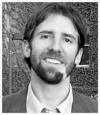

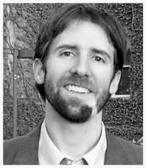

bio

```css
img[alt=bio] { width: 100px; }
```

### Video Links

The most basic way to create a video link is to add a hyperlink to a photo:

```
[   ![](youtube-image.png)  ](www.website-address.com)
```

The annoying part is that you need an image of your video as well as a link. You can search for your video name in images and find an appropriate image. Or there is a trick on YouTube - they create and save images for each video according to the following format:

```
https://img.youtube.com/vi/<insert-youtube-video-id-here>/0.jpg
```

So, for example, the link for Rick Astley, Never Going to Give You Up is:

https://www.youtube.com/watch?v=dQw4w9WgXcQ

Which means the image file will be:

```
https://img.youtube.com/vi/dQw4w9WgXcQ/0.jpg
```

[figure not shown]

### iframes

This basic formula of adding a hyperlink to a photo will work for any photos in Markdown. If you are working with videos, however, there is a better option called an iframe.

This format was created for embedding nicely-formatted videos into HTML pages, and allowing the user to play the video directly from the current page without having to go to YouTube.

To find the iframe info, just click on the **Share** button, then click **Embed**. You will see the following info:

```
<iframe width="560" height="315" src="https://www.youtube.com/embed/dQw4w9WgXcQ" frameborder="0" allow="autoplay; encrypted-media" allowfullscreen></iframe>
```

Paste this code into Markdown, and you are ready to rick and roll.

[video not shown]